# Results: lab_2.sas

The REG Procedure

| Number of Observations Read | 133 |
| --- | --- |
| Number of Observations Used | 133 |

| Descriptive Statistics Variable | Descriptive Statistics Sum | Descriptive Statistics Mean | Descriptive Statistics Uncorrected SS | Descriptive Statistics Variance | Descriptive Statistics Standard Deviation |
| --- | --- | --- | --- | --- | --- |
| Intercept | 133.00000 | 1.00000 | 133.00000 | 0 | 0 |
| adult_mortality | 21451 | 161.28571 | 4776433 | 9974.94805 | 99.87466 |
| infant_deaths | 234.96510 | 1.76665 | 757.37876 | 2.59300 | 1.61028 |
| alcohol | 401.09000 | 3.01571 | 3403.15730 | 16.61806 | 4.07653 |
| hepatitis_b | 10688 | 80.36090 | 941430 | 625.24755 | 25.00495 |
| measles | 415.49148 | 3.12400 | 2481.24784 | 8.96405 | 2.99400 |
| bmi | 5393.60000 | 40.55338 | 277507 | 445.29023 | 21.10190 |
| under_five_deaths | 257.26664 | 1.93434 | 881.56460 | 2.90852 | 1.70544 |
| polio | 10720 | 80.60150 | 953506 | 677.71121 | 26.03289 |
| total_expenditure | 250.47092 | 1.88324 | 492.71249 | 0.15921 | 0.39901 |
| diphtheria | 10979 | 82.54887 | 978257 | 545.09797 | 23.34733 |
| hiv_aids | 103.20000 | 0.77594 | 378.84000 | 2.26336 | 1.50445 |
| thinness_1_19_years | 624.50000 | 4.69549 | 5435.69000 | 18.96483 | 4.35486 |
| thinness_5_9_years | 637.10000 | 4.79023 | 5663.17000 | 19.78271 | 4.44778 |
| income_composition_of_resources | 89.20900 | 0.67074 | 62.89031 | 0.02314 | 0.15210 |
| schooling | 1681.10000 | 12.63985 | 22312 | 8.05196 | 2.83760 |
| gdp_per_capita | -887.97330 | -6.67649 | 6947.07753 | 7.71615 | 2.77780 |
| life_expectancy | 9388.50000 | 70.59023 | 671121 | 63.51892 | 7.96988 |

| Correlation Variable | Correlation adult_mortality | Correlation infant_deaths | Correlation alcohol | Correlation hepatitis_b | Correlation measles | Correlation bmi | Correlation under_five_deaths | Correlation polio | Correlation total_expenditure | Correlation diphtheria | Correlation hiv_aids | Correlation thinness_1_19_years | Correlation thinness_5_9_years | Correlation income_composition_of_resources | Correlation schooling | Correlation gdp_per_capita | Correlation life_expectancy |
| --- | --- | --- | --- | --- | --- | --- | --- | --- | --- | --- | --- | --- | --- | --- | --- | --- | --- |
| adult_mortality | 1.0000 | 0.3986 | -0.2531 | -0.1474 | 0.1396 | -0.3397 | 0.4169 | -0.3135 | -0.1910 | -0.2400 | 0.6145 | 0.2528 | 0.2556 | -0.5979 | -0.4823 | -0.2066 | -0.7360 |
| infant_deaths | 0.3986 | 1.0000 | -0.3186 | -0.2405 | 0.5255 | -0.4370 | 0.9957 | -0.3220 | -0.1709 | -0.3211 | 0.2661 | 0.5169 | 0.5204 | -0.5758 | -0.5338 | -0.5537 | -0.5610 |
| alcohol | -0.2531 | -0.3186 | 1.0000 | 0.1977 | -0.0217 | 0.4437 | -0.3149 | 0.2748 | 0.2390 | 0.2610 | -0.2203 | -0.3786 | -0.3730 | 0.6155 | 0.5844 | 0.2480 | 0.5130 |
| hepatitis_b | -0.1474 | -0.2405 | 0.1977 | 1.0000 | -0.1158 | 0.1290 | -0.2499 | 0.5193 | 0.1100 | 0.8983 | -0.3334 | -0.0350 | -0.0822 | 0.2779 | 0.2973 | 0.0466 | 0.3747 |
| measles | 0.1396 | 0.5255 | -0.0217 | -0.1158 | 1.0000 | -0.1956 | 0.5237 | -0.1888 | -0.1709 | -0.1596 | 0.0195 | 0.3528 | 0.3654 | -0.1757 | -0.1697 | -0.1885 | -0.2107 |
| bmi | -0.3397 | -0.4370 | 0.4437 | 0.1290 | -0.1956 | 1.0000 | -0.4434 | 0.1684 | 0.1963 | 0.1479 | -0.2639 | -0.4879 | -0.5057 | 0.6133 | 0.5959 | 0.2218 | 0.5353 |
| under_five_deaths | 0.4169 | 0.9957 | -0.3149 | -0.2499 | 0.5237 | -0.4434 | 1.0000 | -0.3310 | -0.1697 | -0.3354 | 0.2906 | 0.5160 | 0.5168 | -0.5983 | -0.5532 | -0.5597 | -0.5870 |
| polio | -0.3135 | -0.3220 | 0.2748 | 0.5193 | -0.1888 | 0.1684 | -0.3310 | 1.0000 | 0.2691 | 0.5920 | -0.3530 | -0.1717 | -0.1718 | 0.4330 | 0.3792 | 0.1728 | 0.4887 |
| total_expenditure | -0.1910 | -0.1709 | 0.2390 | 0.1100 | -0.1709 | 0.1963 | -0.1697 | 0.2691 | 1.0000 | 0.1244 | -0.1075 | -0.2153 | -0.2544 | 0.2480 | 0.2857 | 0.0739 | 0.3020 |
| diphtheria | -0.2400 | -0.3211 | 0.2610 | 0.8983 | -0.1596 | 0.1479 | -0.3354 | 0.5920 | 0.1244 | 1.0000 | -0.3950 | -0.0778 | -0.1278 | 0.3923 | 0.3783 | 0.1197 | 0.4666 |
| hiv_aids | 0.6145 | 0.2661 | -0.2203 | -0.3334 | 0.0195 | -0.2639 | 0.2906 | -0.3530 | -0.1075 | -0.3950 | 1.0000 | 0.1663 | 0.1459 | -0.4595 | -0.3663 | -0.1011 | -0.6099 |
| thinness_1_19_years | 0.2528 | 0.5169 | -0.3786 | -0.0350 | 0.3528 | -0.4879 | 0.5160 | -0.1717 | -0.2153 | -0.0778 | 0.1663 | 1.0000 | 0.9682 | -0.5047 | -0.4950 | -0.1675 | -0.4542 |
| thinness_5_9_years | 0.2556 | 0.5204 | -0.3730 | -0.0822 | 0.3654 | -0.5057 | 0.5168 | -0.1718 | -0.2544 | -0.1278 | 0.1459 | 0.9682 | 1.0000 | -0.4957 | -0.4863 | -0.1610 | -0.4493 |
| income_composition_of_resources | -0.5979 | -0.5758 | 0.6155 | 0.2779 | -0.1757 | 0.6133 | -0.5983 | 0.4330 | 0.2480 | 0.3923 | -0.4595 | -0.5047 | -0.4957 | 1.0000 | 0.9198 | 0.3426 | 0.8973 |
| schooling | -0.4823 | -0.5338 | 0.5844 | 0.2973 | -0.1697 | 0.5959 | -0.5532 | 0.3792 | 0.2857 | 0.3783 | -0.3663 | -0.4950 | -0.4863 | 0.9198 | 1.0000 | 0.2890 | 0.7989 |
| gdp_per_capita | -0.2066 | -0.5537 | 0.2480 | 0.0466 | -0.1885 | 0.2218 | -0.5597 | 0.1728 | 0.0739 | 0.1197 | -0.1011 | -0.1675 | -0.1610 | 0.3426 | 0.2890 | 1.0000 | 0.2685 |
| life_expectancy | -0.7360 | -0.5610 | 0.5130 | 0.3747 | -0.2107 | 0.5353 | -0.5870 | 0.4887 | 0.3020 | 0.4666 | -0.6099 | -0.4542 | -0.4493 | 0.8973 | 0.7989 | 0.2685 | 1.0000 |

The REG Procedure

Model: MODEL1

Dependent Variable: life_expectancy

| Number of Observations Read | 133 |
| --- | --- |
| Number of Observations Used | 133 |

| Analysis of Variance Source | Analysis of Variance DF | Analysis of Variance Sum of Squares | Analysis of Variance Mean Square | Analysis of Variance F Value | Analysis of Variance Pr > F |
| --- | --- | --- | --- | --- | --- |
| Model | 16 | 7583.99675 | 473.99980 | 68.69 | <.0001 |
| Error | 116 | 800.50054 | 6.90087 |  |  |
| Corrected Total | 132 | 8384.49729 |  |  |  |

| Root MSE | 2.62695 | R-Square | 0.9045 |
| --- | --- | --- | --- |
| Dependent Mean | 70.59023 | Adj R-Sq | 0.8914 |
| Coeff Var | 3.72141 |  |  |

| Parameter Estimates Variable | Parameter Estimates DF | Parameter Estimates Parameter Estimate | Parameter Estimates Standard Error | Parameter Estimates t Value | Parameter Estimates Pr > \|t\| |
| --- | --- | --- | --- | --- | --- |
| Intercept | 1 | 46.83222 | 2.66585 | 17.57 | <.0001 |
| adult_mortality | 1 | -0.01893 | 0.00344 | -5.51 | <.0001 |
| infant_deaths | 1 | 2.50203 | 1.71501 | 1.46 | 0.1473 |
| alcohol | 1 | 0.00619 | 0.07762 | 0.08 | 0.9366 |
| hepatitis_b | 1 | 0.04273 | 0.02176 | 1.96 | 0.0520 |
| measles | 1 | -0.04186 | 0.09657 | -0.43 | 0.6655 |
| bmi | 1 | -0.00423 | 0.01489 | -0.28 | 0.7771 |
| under_five_deaths | 1 | -2.66143 | 1.67095 | -1.59 | 0.1139 |
| polio | 1 | 0.00550 | 0.01193 | 0.46 | 0.6452 |
| total_expenditure | 1 | 1.45814 | 0.64047 | 2.28 | 0.0246 |
| diphtheria | 1 | -0.01156 | 0.02564 | -0.45 | 0.6528 |
| hiv_aids | 1 | -0.52709 | 0.21412 | -2.46 | 0.0153 |
| thinness_1_19_years | 1 | -0.14925 | 0.23087 | -0.65 | 0.5193 |
| thinness_5_9_years | 1 | 0.11006 | 0.22636 | 0.49 | 0.6277 |
| income_composition_of_resources | 1 | 37.39119 | 4.95379 | 7.55 | <.0001 |
| schooling | 1 | -0.27796 | 0.21981 | -1.26 | 0.2086 |
| gdp_per_capita | 1 | -0.17526 | 0.10496 | -1.67 | 0.0977 |

The REG Procedure

Model: MODEL1

Dependent Variable: life_expectancy

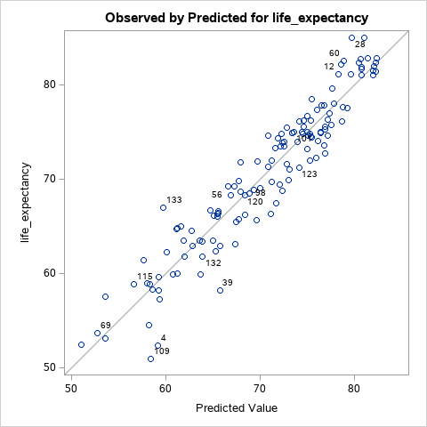

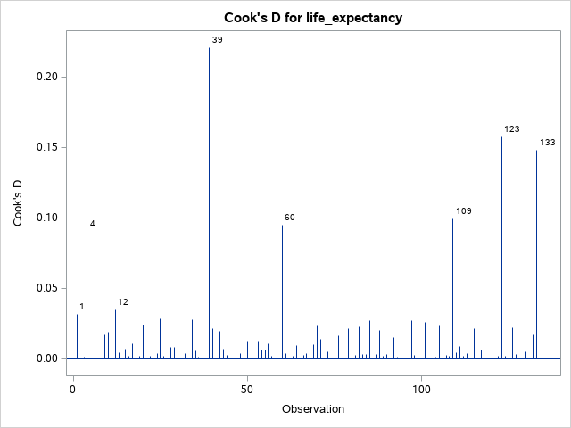

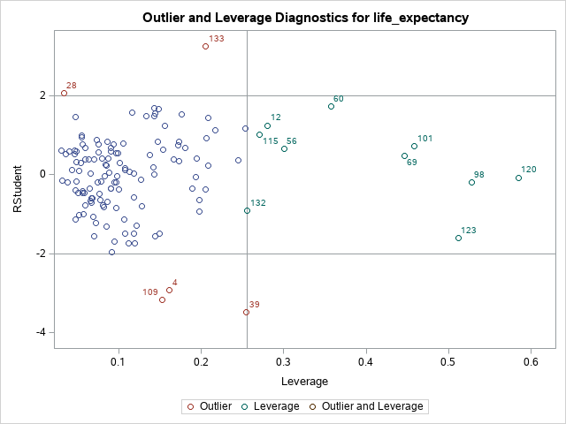

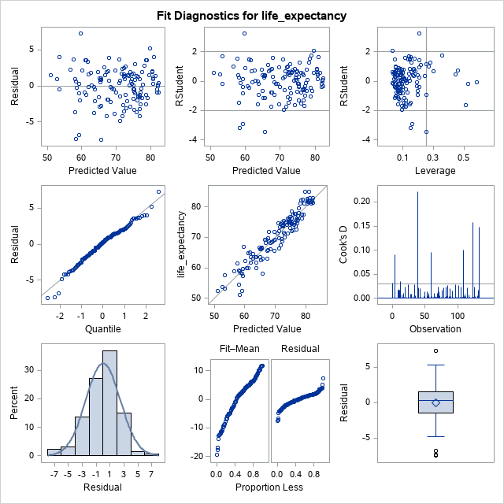

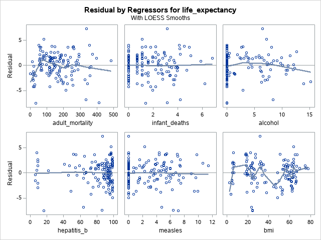

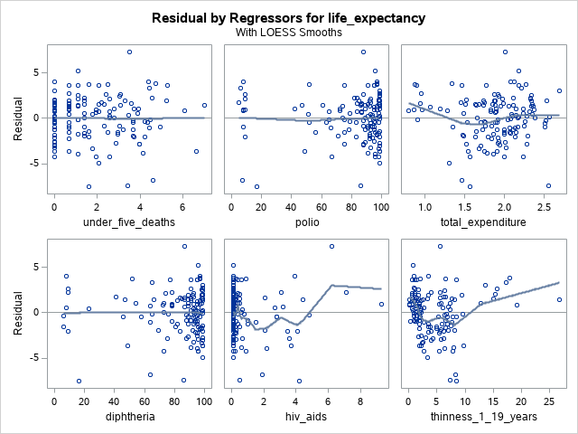

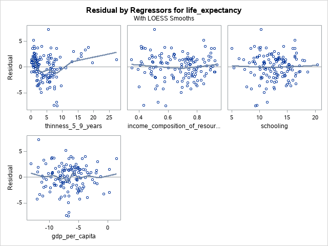

The UNIVARIATE Procedure

Variable: liekanos (Residual)

| Moments |  |  |  |
| --- | --- | --- | --- |
| N | 133 | Sum Weights | 133 |
| Mean | 0 | Sum Observations | 0 |
| Std Deviation | 2.46259985 | Variance | 6.06439805 |
| Skewness | -0.3960616 | Kurtosis | 0.76324913 |
| Uncorrected SS | 800.500542 | Corrected SS | 800.500542 |
| Coeff Variation | . | Std Error Mean | 0.21353449 |

| Basic Statistical Measures Location | Basic Statistical Measures Location | Basic Statistical Measures Variability | Basic Statistical Measures Variability |
| --- | --- | --- | --- |
| Mean | 0.000000 | Std Deviation | 2.46260 |
| Median | 0.242600 | Variance | 6.06440 |
| Mode | . | Range | 14.82465 |
|  |  | Interquartile Range | 3.07755 |

| Tests for Location: Mu0=0 Test | Tests for Location: Mu0=0 Statistic | Tests for Location: Mu0=0 Statistic | Tests for Location: Mu0=0 p Value | Tests for Location: Mu0=0 p Value |
| --- | --- | --- | --- | --- |
| Student's t | t | 0 | Pr > \|t\| | 1.0000 |
| Sign | M | 5.5 | Pr >= \|M\| | 0.3860 |
| Signed Rank | S | 184.5 | Pr >= \|S\| | 0.6802 |

| Tests for Normality Test | Tests for Normality Statistic | Tests for Normality Statistic | Tests for Normality p Value | Tests for Normality p Value |
| --- | --- | --- | --- | --- |
| Shapiro-Wilk | W | 0.981952 | Pr < W | 0.0749 |
| Kolmogorov-Smirnov | D | 0.060241 | Pr > D | >0.1500 |
| Cramer-von Mises | W-Sq | 0.100101 | Pr > W-Sq | 0.1135 |
| Anderson-Darling | A-Sq | 0.63253 | Pr > A-Sq | 0.0979 |

| Quantiles (Definition 5) Level | Quantiles (Definition 5) Quantile |
| --- | --- |
| 100% Max | 7.29846 |
| 99% | 5.24701 |
| 95% | 3.70569 |
| 90% | 2.75514 |
| 75% Q3 | 1.54574 |
| 50% Median | 0.24260 |
| 25% Q1 | -1.53181 |
| 10% | -3.19417 |
| 5% | -4.20659 |
| 1% | -7.38714 |
| 0% Min | -7.52618 |

| Extreme Observations Lowest Value | Extreme Observations Lowest Obs | Extreme Observations Highest Value | Extreme Observations Highest Obs |
| --- | --- | --- | --- |
| -7.52618 | 39 | 3.85110 | 10 |
| -7.38714 | 109 | 3.97536 | 34 |
| -6.80592 | 4 | 4.04576 | 85 |
| -4.87310 | 126 | 5.24701 | 28 |
| -4.24873 | 79 | 7.29846 | 133 |

The REG Procedure

Model: MODEL1

Dependent Variable: life_expectancy

| Number of Observations Read | 133 |
| --- | --- |
| Number of Observations Used | 133 |

Stepwise Selection: Step 1

Variable income_composition_of_resources Entered: R-Square = 0.8052 and C(p) = 107.7301

| Analysis of Variance Source | Analysis of Variance DF | Analysis of Variance Sum of Squares | Analysis of Variance Mean Square | Analysis of Variance F Value | Analysis of Variance Pr > F |
| --- | --- | --- | --- | --- | --- |
| Model | 1 | 6750.85451 | 6750.85451 | 541.34 | <.0001 |
| Error | 131 | 1633.64278 | 12.47056 |  |  |
| Corrected Total | 132 | 8384.49729 |  |  |  |

| Variable | Parameter Estimate | Standard Error | Type II SS | F Value | Pr > F |
| --- | --- | --- | --- | --- | --- |
| Intercept | 39.05390 | 1.38958 | 9850.25730 | 789.88 | <.0001 |
| income_composition_of_resources | 47.01690 | 2.02077 | 6750.85451 | 541.34 | <.0001 |

Bounds on condition number: 1, 1

Stepwise Selection: Step 2

Variable adult_mortality Entered: R-Square = 0.8671 and C(p) = 34.4953

| Analysis of Variance Source | Analysis of Variance DF | Analysis of Variance Sum of Squares | Analysis of Variance Mean Square | Analysis of Variance F Value | Analysis of Variance Pr > F |
| --- | --- | --- | --- | --- | --- |
| Model | 2 | 7270.03980 | 3635.01990 | 424.02 | <.0001 |
| Error | 130 | 1114.45750 | 8.57275 |  |  |
| Corrected Total | 132 | 8384.49729 |  |  |  |

| Variable | Parameter Estimate | Standard Error | Type II SS | F Value | Pr > F |
| --- | --- | --- | --- | --- | --- |
| Intercept | 49.57292 | 1.77607 | 6678.62381 | 779.05 | <.0001 |
| adult_mortality | -0.02477 | 0.00318 | 519.18528 | 60.56 | <.0001 |
| income_composition_of_resources | 37.29114 | 2.09023 | 2728.63279 | 318.29 | <.0001 |

Bounds on condition number: 1.5564, 6.2255

Stepwise Selection: Step 3

Variable hepatitis_b Entered: R-Square = 0.8857 and C(p) = 13.8226

| Analysis of Variance Source | Analysis of Variance DF | Analysis of Variance Sum of Squares | Analysis of Variance Mean Square | Analysis of Variance F Value | Analysis of Variance Pr > F |
| --- | --- | --- | --- | --- | --- |
| Model | 3 | 7426.50076 | 2475.50025 | 333.34 | <.0001 |
| Error | 129 | 957.99654 | 7.42633 |  |  |
| Corrected Total | 132 | 8384.49729 |  |  |  |

| Variable | Parameter Estimate | Standard Error | Type II SS | F Value | Pr > F |
| --- | --- | --- | --- | --- | --- |
| Intercept | 47.45920 | 1.71600 | 5680.40603 | 764.90 | <.0001 |
| adult_mortality | -0.02510 | 0.00296 | 532.84218 | 71.75 | <.0001 |
| hepatitis_b | 0.04534 | 0.00988 | 156.46096 | 21.07 | <.0001 |
| income_composition_of_resources | 35.09015 | 2.00368 | 2277.66518 | 306.70 | <.0001 |

Bounds on condition number: 1.6509, 12.878

Stepwise Selection: Step 4

Variable hiv_aids Entered: R-Square = 0.8925 and C(p) = 7.6163

| Analysis of Variance Source | Analysis of Variance DF | Analysis of Variance Sum of Squares | Analysis of Variance Mean Square | Analysis of Variance F Value | Analysis of Variance Pr > F |
| --- | --- | --- | --- | --- | --- |
| Model | 4 | 7483.13167 | 1870.78292 | 265.66 | <.0001 |
| Error | 128 | 901.36563 | 7.04192 |  |  |
| Corrected Total | 132 | 8384.49729 |  |  |  |

| Variable | Parameter Estimate | Standard Error | Type II SS | F Value | Pr > F |
| --- | --- | --- | --- | --- | --- |
| Intercept | 48.09872 | 1.68615 | 5730.16018 | 813.72 | <.0001 |
| adult_mortality | -0.02040 | 0.00333 | 264.73026 | 37.59 | <.0001 |
| hepatitis_b | 0.03714 | 0.01004 | 96.31594 | 13.68 | 0.0003 |
| hiv_aids | -0.58245 | 0.20539 | 56.63091 | 8.04 | 0.0053 |
| income_composition_of_resources | 34.66233 | 1.95695 | 2209.25742 | 313.73 | <.0001 |

Bounds on condition number: 2.0708, 26.814

Stepwise Selection: Step 5

Variable total_expenditure Entered: R-Square = 0.8970 and C(p) = 4.1881

| Analysis of Variance Source | Analysis of Variance DF | Analysis of Variance Sum of Squares | Analysis of Variance Mean Square | Analysis of Variance F Value | Analysis of Variance Pr > F |
| --- | --- | --- | --- | --- | --- |
| Model | 5 | 7520.59056 | 1504.11811 | 221.12 | <.0001 |
| Error | 127 | 863.90673 | 6.80242 |  |  |
| Corrected Total | 132 | 8384.49729 |  |  |  |

| Variable | Parameter Estimate | Standard Error | Type II SS | F Value | Pr > F |
| --- | --- | --- | --- | --- | --- |
| Intercept | 46.01582 | 1.87996 | 4075.49110 | 599.12 | <.0001 |
| adult_mortality | -0.01982 | 0.00328 | 248.41814 | 36.52 | <.0001 |
| hepatitis_b | 0.03577 | 0.00989 | 89.00457 | 13.08 | 0.0004 |
| total_expenditure | 1.38367 | 0.58964 | 37.45889 | 5.51 | 0.0205 |
| hiv_aids | -0.60805 | 0.20216 | 61.53858 | 9.05 | 0.0032 |
| income_composition_of_resources | 33.93718 | 1.94805 | 2064.49803 | 303.49 | <.0001 |

Bounds on condition number: 2.0827, 39.209

All variables left in the model are significant at the 0.0500 level.

No other variable met the 0.0500 significance level for entry into the model.

| Summary of Stepwise Selection Step | Summary of Stepwise Selection Variable Entered | Summary of Stepwise Selection Variable Removed | Summary of Stepwise Selection Number Vars In | Summary of Stepwise Selection Partial R-Square | Summary of Stepwise Selection Model R-Square | Summary of Stepwise Selection C(p) | Summary of Stepwise Selection F Value | Summary of Stepwise Selection Pr > F |
| --- | --- | --- | --- | --- | --- | --- | --- | --- |
| 1 | income_composition_of_resources |  | 1 | 0.8052 | 0.8052 | 107.730 | 541.34 | <.0001 |
| 2 | adult_mortality |  | 2 | 0.0619 | 0.8671 | 34.4953 | 60.56 | <.0001 |
| 3 | hepatitis_b |  | 3 | 0.0187 | 0.8857 | 13.8226 | 21.07 | <.0001 |
| 4 | hiv_aids |  | 4 | 0.0068 | 0.8925 | 7.6163 | 8.04 | 0.0053 |
| 5 | total_expenditure |  | 5 | 0.0045 | 0.8970 | 4.1881 | 5.51 | 0.0205 |

The REG Procedure

Model: MODEL1

Dependent Variable: life_expectancy

| Number of Observations Read | 133 |
| --- | --- |
| Number of Observations Used | 133 |

| Analysis of Variance Source | Analysis of Variance DF | Analysis of Variance Sum of Squares | Analysis of Variance Mean Square | Analysis of Variance F Value | Analysis of Variance Pr > F |
| --- | --- | --- | --- | --- | --- |
| Model | 5 | 7520.59056 | 1504.11811 | 221.12 | <.0001 |
| Error | 127 | 863.90673 | 6.80242 |  |  |
| Corrected Total | 132 | 8384.49729 |  |  |  |

| Root MSE | 2.60814 | R-Square | 0.8970 |
| --- | --- | --- | --- |
| Dependent Mean | 70.59023 | Adj R-Sq | 0.8929 |
| Coeff Var | 3.69477 |  |  |

| Parameter Estimates Variable | Parameter Estimates DF | Parameter Estimates Parameter Estimate | Parameter Estimates Standard Error | Parameter Estimates t Value | Parameter Estimates Pr > \|t\| | Parameter Estimates Standardized Estimate | Parameter Estimates Squared Partial Corr Type II | Parameter Estimates Variance Inflation | Parameter Estimates 95% Confidence Limits | Parameter Estimates 95% Confidence Limits |
| --- | --- | --- | --- | --- | --- | --- | --- | --- | --- | --- |
| Intercept | 1 | 46.01582 | 1.87996 | 24.48 | <.0001 | 0 | . | 0 | 42.29571 | 49.73592 |
| adult_mortality | 1 | -0.01982 | 0.00328 | -6.04 | <.0001 | -0.24841 | 0.22333 | 2.08270 | -0.02631 | -0.01333 |
| hepatitis_b | 1 | 0.03577 | 0.00989 | 3.62 | 0.0004 | 0.11222 | 0.09340 | 1.18635 | 0.01620 | 0.05534 |
| total_expenditure | 1 | 1.38367 | 0.58964 | 2.35 | 0.0205 | 0.06927 | 0.04156 | 1.07411 | 0.21688 | 2.55045 |
| hiv_aids | 1 | -0.60805 | 0.20216 | -3.01 | 0.0032 | -0.11478 | 0.06650 | 1.79495 | -1.00808 | -0.20801 |
| income_composition_of_resources | 1 | 33.93718 | 1.94805 | 17.42 | <.0001 | 0.64768 | 0.70499 | 1.70368 | 30.08234 | 37.79202 |

The REG Procedure

Model: MODEL1

Dependent Variable: life_expectancy

| Output Statistics Obs | Output Statistics Dependent Variable | Output Statistics Predicted Value | Output Statistics Std Error Mean Predict | Output Statistics 95% CL Predict | Output Statistics 95% CL Predict | Output Statistics Residual |
| --- | --- | --- | --- | --- | --- | --- |
| 1 | 65.0 | 62.3871 | 0.6088 | 57.0873 | 67.6869 | 2.6129 |
| 2 | 77.8 | 76.5818 | 0.3408 | 71.3769 | 81.7868 | 1.2182 |
| 3 | 75.6 | 77.1048 | 0.4554 | 71.8657 | 82.3439 | -1.5048 |
| 4 | 52.4 | 60.5512 | 0.5112 | 55.2920 | 65.8104 | -8.1512 |
| 5 | 76.3 | 77.4798 | 0.3587 | 72.2702 | 82.6895 | -1.1798 |
| 6 | 74.8 | 74.4794 | 0.3067 | 69.2828 | 79.6760 | 0.3206 |
| 7 | 82.8 | 83.1540 | 0.4971 | 77.9001 | 88.4080 | -0.3540 |
| 8 | 81.5 | 81.7273 | 0.4938 | 76.4745 | 86.9800 | -0.2273 |
| 9 | 72.7 | 75.5435 | 0.2864 | 70.3514 | 80.7355 | -2.8435 |
| 10 | 71.8 | 68.2358 | 0.4954 | 62.9825 | 73.4891 | 3.5642 |
| 11 | 72.3 | 75.3225 | 0.4165 | 70.0961 | 80.5490 | -3.0225 |
| 12 | 81.1 | 79.6840 | 0.7679 | 74.3039 | 85.0641 | 1.4160 |
| 13 | 71.0 | 72.3975 | 0.2856 | 67.2056 | 77.5894 | -1.3975 |
| 14 | 60.0 | 62.1100 | 0.3963 | 56.8897 | 67.3303 | -2.1100 |
| 15 | 69.8 | 67.6708 | 0.3893 | 62.4526 | 72.8891 | 2.1292 |
| 16 | 77.4 | 75.7574 | 0.3732 | 70.5438 | 80.9710 | 1.6426 |
| 17 | 65.7 | 69.2603 | 0.4347 | 64.0281 | 74.4926 | -3.5603 |
| 18 | 75.0 | 75.2512 | 0.3358 | 70.0475 | 80.4548 | -0.2512 |
| 19 | 74.5 | 76.5145 | 0.3500 | 71.3072 | 81.7218 | -2.0145 |
| 20 | 59.9 | 64.4014 | 0.8787 | 58.9553 | 69.8475 | -4.5014 |
| 21 | 59.6 | 59.9896 | 0.6221 | 54.6838 | 65.2954 | -0.3896 |
| 22 | 73.3 | 71.4143 | 0.3350 | 66.2109 | 76.6178 | 1.8857 |
| 23 | 68.7 | 67.1931 | 0.3522 | 61.9852 | 72.4010 | 1.5069 |
| 24 | 57.3 | 59.5135 | 0.5604 | 54.2347 | 64.7924 | -2.2135 |
| 25 | 82.2 | 79.0818 | 0.8634 | 73.6453 | 84.5183 | 3.1182 |
| 26 | 52.5 | 51.2093 | 0.6745 | 45.8785 | 56.5402 | 1.2907 |
| 27 | 53.1 | 54.3906 | 0.5779 | 49.1043 | 59.6768 | -1.2906 |
| 28 | 85.0 | 79.4836 | 0.3742 | 74.2697 | 84.6975 | 5.5164 |
| 29 | 76.1 | 75.3216 | 0.3302 | 70.1194 | 80.5239 | 0.7784 |
| 30 | 74.8 | 73.8572 | 0.2835 | 68.6658 | 79.0487 | 0.9428 |

[output cut: 103 more lines]

| Sum of Residuals | 6.68303E-12 |
| --- | --- |
| Sum of Squared Residuals | 863.90673 |
| Predicted Residual SS (PRESS) | 1002.82532 |

| Obs | _MODEL_ | _TYPE_ | _DEPVAR_ | _RMSE_ | Intercept | adult_mortality | infant_deaths | alcohol | hepatitis_b | measles | bmi | under_five_deaths | polio | total_expenditure | diphtheria | hiv_aids | thinness_1_19_years | thinness_5_9_years | income_composition_of_resources | schooling | gdp_per_capita | life_expectancy | _IN_ | _P_ | _EDF_ | _RSQ_ | _AIC_ | _BIC_ |
| --- | --- | --- | --- | --- | --- | --- | --- | --- | --- | --- | --- | --- | --- | --- | --- | --- | --- | --- | --- | --- | --- | --- | --- | --- | --- | --- | --- | --- |
| 1 | MODEL1 | PARMS | life_expectancy | 2.60814 | 46.0158 | -0.019823 | . | . | 0.035768 | . | . | . | . | 1.38367 | . | -0.60805 | . | . | 33.9372 | . | . | -1 | 5 | 6 | 127 | 0.89696 | 260.858 | 263.599 |